# R Notebook

# Hypthesisis testing - practical

```r
library(tidyverse)
library(infer)
library(beepr)
data(msleep)
beep(8)
```

```r
glimpse(msleep)
```

```
Rows: 83
Columns: 11
$ name         <chr> "Cheetah", "Owl monkey", "Mountain beaver", "Greater short-tailed shrew", "Cow", "Three-toed sloth", "Northern fur seal", "Vesp…
$ genus        <chr> "Acinonyx", "Aotus", "Aplodontia", "Blarina", "Bos", "Bradypus", "Callorhinus", "Calomys", "Canis", "Capreolus", "Capri", "Cavi…
$ vore         <chr> "carni", "omni", "herbi", "omni", "herbi", "herbi", "carni", NA, "carni", "herbi", "herbi", "herbi", "omni", "herbi", "omni", "…
$ order        <chr> "Carnivora", "Primates", "Rodentia", "Soricomorpha", "Artiodactyla", "Pilosa", "Carnivora", "Rodentia", "Carnivora", "Artiodact…
$ conservation <chr> "lc", NA, "nt", "lc", "domesticated", NA, "vu", NA, "domesticated", "lc", "lc", "domesticated", "lc", "domesticated", "lc", NA,…
$ sleep_total  <dbl> 12.1, 17.0, 14.4, 14.9, 4.0, 14.4, 8.7, 7.0, 10.1, 3.0, 5.3, 9.4, 10.0, 12.5, 10.3, 8.3, 9.1, 17.4, 5.3, 18.0, 3.9, 19.7, 2.9, …
$ sleep_rem    <dbl> NA, 1.8, 2.4, 2.3, 0.7, 2.2, 1.4, NA, 2.9, NA, 0.6, 0.8, 0.7, 1.5, 2.2, 2.0, 1.4, 3.1, 0.5, 4.9, NA, 3.9, 0.6, 0.4, 3.5, 1.1, N…
$ sleep_cycle  <dbl> NA, NA, NA, 0.1333333, 0.6666667, 0.7666667, 0.3833333, NA, 0.3333333, NA, NA, 0.2166667, NA, 0.1166667, NA, NA, 0.1500000, 0.3…
$ awake        <dbl> 11.90, 7.00, 9.60, 9.10, 20.00, 9.60, 15.30, 17.00, 13.90, 21.00, 18.70, 14.60, 14.00, 11.50, 13.70, 15.70, 14.90, 6.60, 18.70,…
$ brainwt      <dbl> NA, 0.01550, NA, 0.00029, 0.42300, NA, NA, NA, 0.07000, 0.09820, 0.11500, 0.00550, NA, 0.00640, 0.00100, 0.00660, 0.00014, 0.01…
$ bodywt       <dbl> 50.000, 0.480, 1.350, 0.019, 600.000, 3.850, 20.490, 0.045, 14.000, 14.800, 33.500, 0.728, 4.750, 0.420, 0.060, 1.000, 0.005, 3…
```

## Question 1

Jabberwockies sleep for around 7 hours a night, on average. Perform an appropriate statistical test to determine whether the mean sleep_total in the sampled population of animal types differs from the typical value for jabberwockies.

α=0.05

H0:mu_aniamls_sleep_total = 7 H1 mu_animals_sleep_total != 7

```r
observed_stat <- msleep %>%
  summarise(mean = mean(sleep_total)) %>%
  pull()
```

```r
null_distribution <- msleep %>%
  specify(response = sleep_total) %>%
  hypothesise(null = "point", mu = 7) %>%
  generate(reps = 10000, type = "bootstrap") %>%
  calculate(stat = "mean")
```

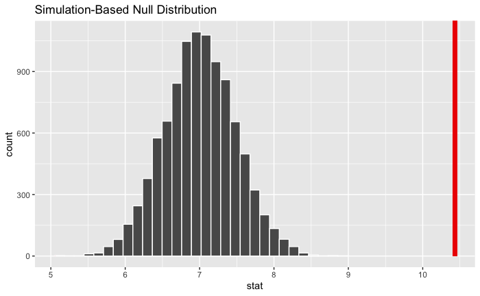

```r
null_distribution %>%
  visualise(bins = 30) +
  shade_p_value(observed_stat, "both")
```

```r
null_distribution %>%
  get_p_value(observed_stat, "both")
```

```
Please be cautious in reporting a p-value of 0. This result is an approximation based on the number of `reps` chosen in the `generate()` step. See `?get_p_value()` for more information.
```

| p_value |
| --- |
| 0 |

Since the p-value is less than α we reject H0 in favour of Ha. We found enough evidence in the sample to suggest that the sample mean is statistically significantly different from the null value.

## Question 2

Perform an appropriate statistical test to determine whether omnivores sleep for significantly longer than herbivores, on average.

α=0.05

H0:mu_sleep_omni - mu sleep_herbivore = 0 H1 mu_sleep_omni - mu sleep_herbivore > 0

```r
h_o_animals <- msleep %>%
  select(vore, sleep_total) %>%
  filter(vore %in% c("omni", "herbi"))
```

```r
h_o_animals %>%
group_by(vore) %>%
  summarise(n = n())
```

| vore | n |
| --- | --- |
| herbi | 32 |
| omni | 20 |

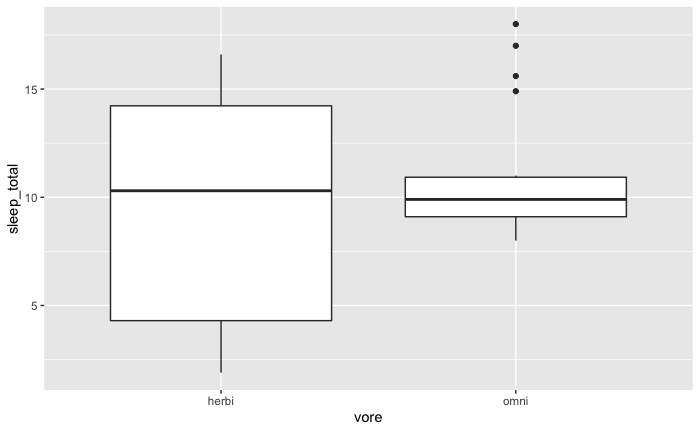

```r
h_o_animals %>%
  ggplot()+
  aes(y = sleep_total, x = vore) +
  geom_boxplot()
```

There is clearly a greater spread of herbivores but the medians do not look too diffierent

```r
observed_stat <- h_o_animals %>%
  specify(sleep_total ~ vore) %>%
  calculate("diff in means", order = c("omni", "herbi"))
```

```r
null_distribution <- h_o_animals %>%
  specify(sleep_total ~ vore) %>%
  hypothesise(null = "independence") %>%
  generate(reps = 10000, type = "permute") %>%
  calculate("diff in means", order = c("omni", "herbi"))
  beep(5)
```

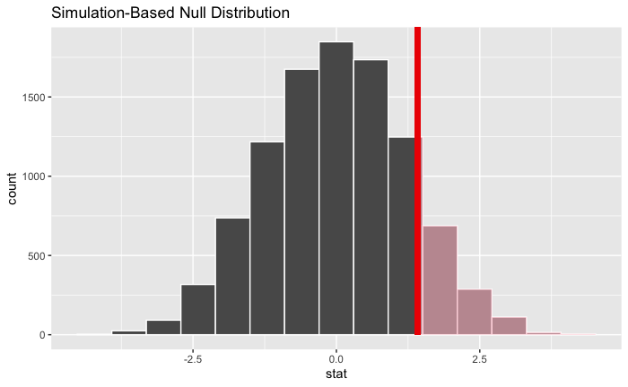

```r
null_distribution %>%
  visualise() +
  shade_p_value(observed_stat, "right")
```

```r
null_distribution %>%
get_p_value(observed_stat, "right")
```

| p_value |
| --- |
| 0.1257 |

The p-value is greater than α and lack sufficient evidence to reject H0 and so we fail to reject H0. Based on our sample, we do not have enough evidence that the mean difference between herbivores and omnivores is statistically significantly different from each other.

## Question 3

Perform an appropriate statistical test to determine whether the proportion of domesticated animal types in the population of animal types is greater than 5%.

H0: πdomesticated = 0.05 Ha: πdomesticated > 0.05

```r
domesticated <- msleep %>%
  mutate(conservation = coalesce(conservation, "not_listed")) %>%
  mutate(is_domesticated = ifelse(conservation == "domesticated", "domesticated", "not_domesticated"))
```

```r
domesticated %>%
  group_by(is_domesticated) %>%
  summarise(prop = n()/ nrow(domesticated))
```

| is_domesticated | prop |
| --- | --- |
| domesticated | 0.1204819 |
| not_domesticated | 0.8795181 |

```r
null_distribution <- domesticated %>%
  specify(response = is_domesticated, success = "domesticated") %>%
  hypothesise(null = "point", p = 0.05) %>%
  generate(reps = 10000, type = "simulate") %>%
  calculate(stat = "prop")
```

```r
observed_stat <- domesticated %>%
specify(response = is_domesticated, success = "domesticated") %>%
  calculate(stat = "prop")
observed_stat
```

| stat |
| --- |
| 0.1204819 |

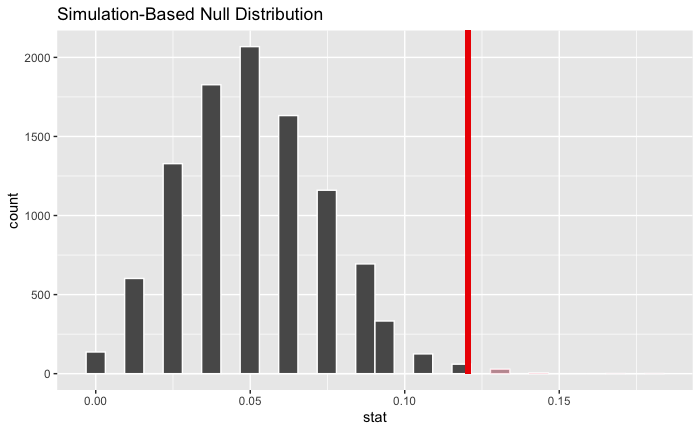

```r
null_distribution %>%
  visualise(bins = 30) +
  shade_p_value(obs_stat = observed_stat, direction = "right")
```

```r
null_distribution %>%
get_p_value(obs_stat = observed_stat, direction = "greater")
```

| p_value |
| --- |
| 0.0094 |

The p-value is less than α we reject H0 in favour of Ha. We found enough evidence in the sample to suggest that the sample proportion is statistically significantly different greater than the null value.

# Hypothesis testing - interpretation

## Defining the Hypothesis

### Question 1

You work for a independent coffee shop. You’ve performed a small survey in the local town and found that 40% of the people you randomly asked were aware of your shop in the town. You then conduct a marketing campaign by flyering local venues and targeting advertisements on social media. Finally you conduct a second small random survey in the town, asking if people are aware of your coffee shop. You want to test the hypothesis that the campaign has significantly increased awareness of the shop.

H0: πaware_of_shop = 0.40 Ha: πaware_of_shop > 0.40

H0 = the proportion of people aware of the shop = 0.4 Ha = the propprotion of people aware of the shop > 0.4

As we are using proportions we are using simulation to gather the results.

### Question 2

You work for a website design company and have performed an A/B test on the position of a banner on a website page promoting a particular item.

In the current test, the first group continues to be shown the banner at the right hand side of the webpage (its usual position) while the test group is shown it at the top of the page. The performance metric we will be testing is click through rate (CTR) on the banner, i.e. what proportion of users click on the banner

a = right b = top

H0: pclicks_a - pclicks_B = 0 Ha pclicks_a - pclicks_B < 0

H0 = the proportion of clicks on right minus the proportion of clicks on top is equal to 0 Ha the proportion of clicks on right minus the proportion of clicks on top is less than 0

since we are using 2 samples we are using permutation

### Question 3

You work as an analyst for a car manufacturing company - they have specific standards they must meet for standards and regulation purposes. You have been asked to check the quality control of the manufacture of a particular car part. The part must have a width of 145mm, with a small (given) level of tolerance. You have been given data on a sample of 1,000 parts produced over the period of a week.

H0:mu_width_part = 145 H1 mu_width_part != 145

H0 mean width of part = 145 Ha mean width of part not equal to 145

since we are working with 1 mean we will be using bootstraping

## Interpreting the results

### Question 1

Coffee shop problem. Significance level: 0.05, calculated p-value: 0.07

the p-value is greater than α then we lack sufficient evidence to reject H0 and so we fail to reject H0. Based on our sample, we do not have enough evidence that the proportion is statistically significantly greater than the null value.

### Question 2

Website company problem. Significance level: 0.01, p-value: 0.006

The p-value is less than α we reject H0 in favour of Ha. We found enough evidence in the sample to suggest that the sample proportion is statistically significantly less than the null value

### Question 3

Manufacturing company problem. Significance level: 0.05, p-value: 0.55

The p-value is greater than α then we lack sufficient evidence to reject H0 and so we fail to reject H0. Based on our sample, we do not have enough evidence that the mean/proportion is statistically significantly different from the null value.

# Extension

```r
transactions <- read_csv("data/online_retail_subset.csv")
```

For the first section we are interested in the purchase of two particular items:

item A - ‘HEART OF WICKER SMALL’ (StockCode 22469) item B - ‘LARGE CAKE TOWEL PINK SPOTS’ (StockCode 21110)

```r
association_items <- transactions %>%
  filter(StockCode %in% c(22469, 21110))
```

## Question 1

```r
supp_a <- transactions %>%
  filter(StockCode %in% c(22469)) %>%
  summarise(support = n()/nrow(transactions)) %>%
  pull(support)

supp_a
```

```
[1] 0.003666667
```

## Question 2

```r
multiple_items <- transactions %>%
  filter(StockCode %in% c(22469, 21110)) %>%
  group_by(InvoiceNo, Description) %>%
  summarise(n = n())
```

```r
num_a_and_b =transactions %>%
  filter(StockCode %in% c(22469, 21110)) %>%
  distinct(InvoiceNo, StockCode) %>%
  group_by(InvoiceNo) %>%
  summarise(count = n()) %>%
  filter(count > 1) %>%
  summarise(n()) %>%
  pull()
```

```r
supp_atob <- num_a_and_b/nrow(transactions)

supp_atob
```

```
[1] 0.0001666667
```

```r
conf_atob <- supp_atob/supp_a
conf_atob
```

```
[1] 0.04545455
```

```r
supp_b <- transactions %>%
  filter(StockCode %in% c(21110)) %>%
  summarise(support = n()/nrow(transactions)) %>%
  pull(support)

supp_b
```

```
[1] 0.0004666667
```

```r
lift_atob <- supp_atob/(supp_a*supp_b)

lift_atob
```

```
[1] 97.4026
```

```r
library(arules)
library(arulesViz)
transactions_reformat <- transactions %>%
  select(InvoiceNo, Description) %>%
  na.omit()

write_csv(transactions_reformat, "transactions_reformat.csv")

apriori_format <- read.transactions("transactions_reformat.csv", format = "single", sep = ",", header = TRUE, cols = c("InvoiceNo", "Description"))
```

```
EOF within quoted string
```

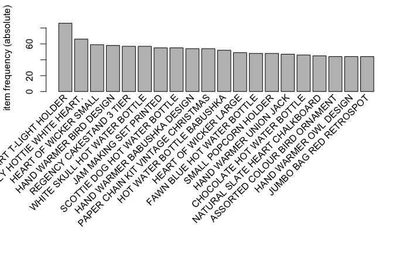

```r
itemFrequencyPlot(apriori_format,topN=20,type="absolute")
```

```r
rules <- apriori(apriori_format, parameter = list(supp = 0.01, conf = 0.8, maxlen = 4))
```

```
Apriori

Parameter specification:
```

|  | confidence | minval | smax | arem | aval | originalSupport | maxtime | support | minlen | maxlen | target | ext |
| --- | --- | --- | --- | --- | --- | --- | --- | --- | --- | --- | --- | --- |
|  | 0.8 | 0.1 | 1 | none | FALSE | TRUE | 5 | 0.01 | 1 | 4 | rules | TRUE |

```
Algorithmic control:
```

|  | filter | tree | heap | memopt | load | sort | verbose |
| --- | --- | --- | --- | --- | --- | --- | --- |
|  | 0.1 | TRUE | TRUE | FALSE | TRUE | 2 | TRUE |

```
Absolute minimum support count: 7

set item appearances ...[0 item(s)] done [0.00s].
set transactions ...[2470 item(s), 786 transaction(s)] done [0.01s].
sorting and recoding items ... [686 item(s)] done [0.00s].
creating transaction tree ... done [0.00s].
checking subsets of size 1 2 3 4
```

```
Mining stopped (maxlen reached). Only patterns up to a length of 4 returned!
```

```
 done [0.01s].
writing ... [8743 rule(s)] done [0.00s].
creating S4 object  ... done [0.00s].
```

```r
beep(8)
```

```r
inspect(rules[1:5])
```

|  | lhs |  | rhs | support | confidence | coverage | lift | count |
| --- | --- | --- | --- | --- | --- | --- | --- | --- |
| [1] | {HAND WARMER RED POLKA DOT} | => | {HAND WARMER UNION JACK} | 0.01017812 | 0.8888889 | 0.01145038 | 14.86525 | 8 |
| [2] | {SILK PURSE BABUSHKA BLUE} | => | {SILK PURSE BABUSHKA RED} | 0.01145038 | 0.8181818 | 0.01399491 | 53.59091 | 9 |
| [3] | {SET/6 RED SPOTTY PAPER PLATES} | => | {SET/6 RED SPOTTY PAPER CUPS} | 0.01017812 | 0.8888889 | 0.01145038 | 63.51515 | 8 |
| [4] | {MONSTERS STENCIL CRAFT} | => | {HAPPY STENCIL CRAFT} | 0.01145038 | 0.9000000 | 0.01272265 | 50.52857 | 9 |
| [5] | {ALPHABET STENCIL CRAFT} | => | {HAPPY STENCIL CRAFT} | 0.01017812 | 0.8000000 | 0.01272265 | 44.91429 | 8 |

```r
summary(rules)
```

```
set of 8743 rules

rule length distribution (lhs + rhs):sizes
   2    3    4
 127 2520 6096

   Min. 1st Qu.  Median    Mean 3rd Qu.    Max.
  2.000   3.000   4.000   3.683   4.000   4.000

summary of quality measures:
    support          confidence        coverage            lift            count
 Min.   :0.01018   Min.   :0.8000   Min.   :0.01018   Min.   : 7.312   Min.   : 8.000
 1st Qu.:0.01018   1st Qu.:0.8889   1st Qu.:0.01018   1st Qu.:17.864   1st Qu.: 8.000
 Median :0.01018   Median :1.0000   Median :0.01018   Median :23.818   Median : 8.000
 Mean   :0.01070   Mean   :0.9506   Mean   :0.01134   Mean   :30.649   Mean   : 8.413
 3rd Qu.:0.01145   3rd Qu.:1.0000   3rd Qu.:0.01272   3rd Qu.:39.300   3rd Qu.: 9.000
 Max.   :0.02799   Max.   :1.0000   Max.   :0.03308   Max.   :78.600   Max.   :22.000

mining info:
```

|  | data | ntransactions | support | confidence |
| --- | --- | --- | --- | --- |
|  | apriori_format | 786 | 0.01 | 0.8 |

```r
rules <- rules %>%
  sort(by = "confidence", decreasing  = TRUE)

inspect(rules[1:5])
```

|  | lhs |  | rhs | support | confidence | coverage | lift | count |
| --- | --- | --- | --- | --- | --- | --- | --- | --- |
| [1] | {HERB MARKER MINT} | => | {HERB MARKER BASIL} | 0.01145038 | 1 | 0.01145038 | 71.45455 | 9 |
| [2] | {HERB MARKER THYME} | => | {HERB MARKER PARSLEY} | 0.01272265 | 1 | 0.01272265 | 78.60000 | 10 |
| [3] | {HERB MARKER PARSLEY} | => | {HERB MARKER THYME} | 0.01272265 | 1 | 0.01272265 | 78.60000 | 10 |
| [4] | {HERB MARKER THYME} | => | {HERB MARKER BASIL} | 0.01272265 | 1 | 0.01272265 | 71.45455 | 10 |
| [5] | {HERB MARKER PARSLEY} | => | {HERB MARKER BASIL} | 0.01272265 | 1 | 0.01272265 | 71.45455 | 10 |

```r
rules<-apriori(data=apriori_format, parameter=list(supp=0.001,conf = 0.15),
               appearance = list(default="rhs",lhs="LARGE CAKE TOWEL PINK SPOTS"),
               control = list(verbose=F))
rules<-sort(rules, decreasing=TRUE,by="confidence")

inspect(rules)
```

|  | lhs |  | rhs | support | confidence | coverage | lift | count |
| --- | --- | --- | --- | --- | --- | --- | --- | --- |
| [1] | {LARGE CAKE TOWEL PINK SPOTS} | => | {SWISS ROLL TOWEL, CHOCOLATE SPOTS} | 0.006361323 | 0.625 | 0.01017812 | 49.125000 | 5 |
| [2] | {LARGE CAKE TOWEL PINK SPOTS} | => | {FAIRY CAKE FLANNEL ASSORTED COLOUR} | 0.006361323 | 0.625 | 0.01017812 | 35.089286 | 5 |
| [3] | {LARGE CAKE TOWEL PINK SPOTS} | => | {SWISS ROLL TOWEL, PINK SPOTS} | 0.005089059 | 0.500 | 0.01017812 | 65.500000 | 4 |
| [4] | {LARGE CAKE TOWEL PINK SPOTS} | => | {VINTAGE UNION JACK MEMOBOARD} | 0.005089059 | 0.500 | 0.01017812 | 24.562500 | 4 |
| [5] | {LARGE CAKE TOWEL PINK SPOTS} | => | {12 PENCILS SMALL TUBE SKULL} | 0.005089059 | 0.500 | 0.01017812 | 20.684211 | 4 |
| [6] | {LARGE CAKE TOWEL PINK SPOTS} | => | {SET/5 RED RETROSPOT LID GLASS BOWLS} | 0.005089059 | 0.500 | 0.01017812 | 13.551724 | 4 |
| [7] | {LARGE CAKE TOWEL PINK SPOTS} | => | {HAND WARMER SCOTTY DOG DESIGN} | 0.005089059 | 0.500 | 0.01017812 | 10.076923 | 4 |
| [8] | {LARGE CAKE TOWEL PINK SPOTS} | => | {SET OF 3 NOTEBOOKS IN PARCEL} | 0.005089059 | 0.500 | 0.01017812 | 17.086957 | 4 |
| [9] | {LARGE CAKE TOWEL PINK SPOTS} | => | {PLEASE ONE PERSON METAL SIGN} | 0.005089059 | 0.500 | 0.01017812 | 9.585366 | 4 |
| [10] | {LARGE CAKE TOWEL PINK SPOTS} | => | {CREAM SLICE FLANNEL CHOCOLATE SPOT} | 0.003816794 | 0.375 | 0.01017812 | 49.125000 | 3 |

[output cut: 166 more lines]

```r
plot(rules,method="graph",shading=NA, engine = "html")
```

[output not shown]

```r
  plot(rules, method = "graph", measure = "support", shading = "lift",
    interactive = FALSE, data = NULL, control = NULL,engine = "html")
```

```
The parameter interactive is deprecated. Use engine='interactive' instead.Too many rules supplied. Only plotting the best 100 rules using lift (change control parameter max if needed)
```

[interactive chart not shown]